# Wellness Tourism Package: Development of strategies to identify and expand customer base

#### Observations

The standard scaler translates the data to how many standard deviations from the mean and does not affect the shape of the overall distribution.

```python
customerData3.drop(["MonthlyIncome"], axis=1, inplace=True) # Dropping since no longer needed
```

```python
customerData3.info()
```

```
<class 'pandas.core.frame.DataFrame'>
Int64Index: 4888 entries, 200000 to 204887
Data columns (total 19 columns):
 #   Column                    Non-Null Count  Dtype
---  ------                    --------------  -----
 0   ProdTaken                 4888 non-null   category
 1   Age                       4888 non-null   float64
 2   TypeofContact             4888 non-null   category
 3   CityTier                  4888 non-null   int64
 4   DurationOfPitch           4888 non-null   float64
 5   Occupation                4888 non-null   category
 6   Gender                    4888 non-null   category
 7   NumberOfPersonVisiting    4888 non-null   int64
 8   NumberOfFollowups         4888 non-null   float64
 9   ProductPitched            4888 non-null   category
 10  PreferredPropertyStar     4888 non-null   float64
 11  MaritalStatus             4888 non-null   category
 12  NumberOfTrips             4888 non-null   float64
 13  Passport                  4888 non-null   category
 14  PitchSatisfactionScore    4888 non-null   int64
 15  OwnCar                    4888 non-null   category
 16  NumberOfChildrenVisiting  4888 non-null   float64
 17  Designation               4888 non-null   category
 18  MonthlyIncome_z_std       4888 non-null   float64
dtypes: category(9), float64(7), int64(3)
memory usage: 593.5 KB
```

```python
# 7.4 Encoding the categorical variables for dummy variables (except target variable)

# Separate out the columns into independent variables and dependent variables
independent_var = customerData3.drop(["ProdTaken"], axis=1)
# ProdTaken goes in dependent variable column
dependent_var = customerData3[["ProdTaken"]]
```

```python
# Encoding the categorical variable using dummy variables
def encode_cat_vars(x):
    x = pd.get_dummies(
        x,
        columns=x.select_dtypes(include=["category"]).columns.tolist(),
        drop_first=True,
    )
    return x
```

```python
independent_var_num = encode_cat_vars(independent_var)
independent_var_num.head()
```

| CustomerID | Age | CityTier | DurationOfPitch | NumberOfPersonVisiting | NumberOfFollowups | PreferredPropertyStar | NumberOfTrips | PitchSatisfactionScore | NumberOfChildrenVisiting | MonthlyIncome_z_std | TypeofContact_Self Enquiry | Occupation_Large Business | Occupation_Salaried | Occupation_Small Business | Gender_Male | ProductPitched_Deluxe | ProductPitched_King | ProductPitched_Standard | ProductPitched_Super Deluxe | MaritalStatus_Married | MaritalStatus_Single | MaritalStatus_Unmarried | Passport_1 | OwnCar_1 | Designation_Executive | Designation_Manager | Designation_Senior Manager | Designation_VP |
| --- | --- | --- | --- | --- | --- | --- | --- | --- | --- | --- | --- | --- | --- | --- | --- | --- | --- | --- | --- | --- | --- | --- | --- | --- | --- | --- | --- | --- |
| 200000 | 41.0 | 3 | 6.0 | 3 | 3.0 | 3.0 | 1.0 | 2 | 0.0 | -0.511461 | 1 | 0 | 1 | 0 | 0 | 1 | 0 | 0 | 0 | 0 | 1 | 0 | 1 | 1 | 0 | 1 | 0 | 0 |
| 200001 | 49.0 | 1 | 14.0 | 3 | 4.0 | 4.0 | 2.0 | 3 | 2.0 | -0.702279 | 0 | 0 | 1 | 0 | 1 | 1 | 0 | 0 | 0 | 0 | 0 | 0 | 0 | 1 | 0 | 1 | 0 | 0 |
| 200002 | 37.0 | 1 | 8.0 | 3 | 4.0 | 3.0 | 7.0 | 3 | 0.0 | -1.374455 | 1 | 0 | 0 | 0 | 1 | 0 | 0 | 0 | 0 | 0 | 1 | 0 | 1 | 0 | 1 | 0 | 0 | 0 |
| 200003 | 33.0 | 1 | 9.0 | 2 | 3.0 | 3.0 | 2.0 | 5 | 1.0 | -1.193366 | 0 | 0 | 1 | 0 | 0 | 0 | 0 | 0 | 0 | 0 | 0 | 0 | 1 | 1 | 1 | 0 | 0 | 0 |
| 200004 | 36.0 | 1 | 8.0 | 2 | 3.0 | 4.0 | 1.0 | 5 | 0.0 | -1.069765 | 1 | 0 | 0 | 1 | 1 | 0 | 0 | 0 | 0 | 0 | 0 | 0 | 0 | 1 | 1 | 0 | 0 | 0 |

```python
independent_var_num.shape
```

```
(4888, 28)
```

#### Observations

We have 28 columns after doing one hot encoding. This completes the data preprocessing section.

### 8. Bagging models

This section will have: decision tree, bagging classifier, random forest. All three types will have: (a) model building, (b) performance evaluation (c) model improvement with hypertuning.

#### Note about model predictions

The ProdTaken column is the dependent variable. We are trying to predict which customers in the dataset would buy a travel package with "Visit with Us". So, we are attempting to predict which of the customers from the test data set will have ProdTaken = 1 or ProdTaken = 0.  
We will use recall and F1 as our most important performance measures.  
The wrong predictions will consist of (a) the customer was predicted to buy a travel package, but did not when the marketing campaign targeted that customer (False Positive) and (b) the customer was predicted to not buy a travel package, but ended up buying a travel package (False negative).  
In terms of cost and resources, the false positives (prediction of ProdTaken = 1) will be more important since the marketing campaign will cost money and resources, and the predictions will drive strategy and revenue forecasts for the travel company as well.

```python
# Creating the training and testing data
# Dependent variable = ProdTaken
X_train, X_test, y_train, y_test = train_test_split(
    independent_var_num,
    dependent_var,
    test_size=0.3,  # test_size = 0.3 is a common split
    random_state=1,
    stratify=dependent_var,
)
# We are using stratify here because there is imbalance in the data (only ~19% for ProdTaken=1)
# stratify=dependent_var will keep relative class frequencies approximately same between train
# and test sets
```

```python
print("Shape of Training set : ", X_train.shape)
print("Shape of Testing set : ", X_test.shape)
print("Percentage of classes in training set:")
print(y_train.value_counts(normalize=True))
print("Percentage of classes in test set:")
print(y_test.value_counts(normalize=True))
```

```
Shape of Training set :  (3421, 28)
Shape of Testing set :  (1467, 28)
Percentage of classes in training set:
ProdTaken
0            0.811751
1            0.188249
dtype: float64
Percentage of classes in test set:
ProdTaken
0            0.811861
1            0.188139
dtype: float64
```

#### Observations

The relative class frequencies between train and test set are approximately the same.

```python
# This will calculate the performance measures for classification model
def model_performance_classification_sklearn(model, predictors, target):
    """
    Function to compute different metrics to check classification model performance

    model: classifier
    predictors: independent variables
    target: dependent variable
    """

    # predicting using the independent variables
    pred = model.predict(predictors)

    acc = accuracy_score(target, pred)  # to compute Accuracy
    recall = recall_score(target, pred)  # to compute Recall
    precision = precision_score(target, pred)  # to compute Precision
    f1 = f1_score(target, pred)  # to compute F1-score

    # creating a dataframe of metrics
    df_perf = pd.DataFrame(
        {
            "Accuracy": acc,
            "Recall": recall,
            "Precision": precision,
            "F1": f1,
        },
        index=[0],
    )

    return df_perf
```

```python
#This function will build the confusion matrix
def confusion_matrix_sklearn(model, predictors, target):
    """
    To plot the confusion_matrix with percentages

    model: classifier
    predictors: independent variables
    target: dependent variable
    """
    y_pred = model.predict(predictors)
    cm = confusion_matrix(target, y_pred)
    labels = np.asarray(
        [
            ["{0:0.0f}".format(item) + "\n{0:.2%}".format(item / cm.flatten().sum())]
            for item in cm.flatten()
        ]
    ).reshape(2, 2)

    plt.figure(figsize=(6, 4))
    sns.heatmap(cm, annot=labels, fmt="")
    plt.ylabel("True label")
    plt.xlabel("Predicted label")
```

#### Decision Tree - without hypertuning

```python
# We will first build a decision tree, then bagging and then random forest
dtree = DecisionTreeClassifier(
    criterion="gini", class_weight={0: 0.19, 1: 0.81}, random_state=1
)
#The weights are decided here based on the relative class frequencies for train and test
```

```python
dtree.fit(X_train, y_train)
```

```
DecisionTreeClassifier(class_weight={0: 0.19, 1: 0.81}, random_state=1)
```

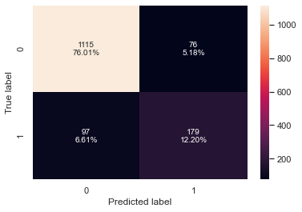

```python
#Confusion matrix is for test set
confusion_matrix_sklearn(dtree, X_test, y_test)
```

#### Observations

True Positive: The model predicted customer will buy a travel package, and customer bought a travel package. This is 12.2% for the decision tree model. False Positive: The model predicted that customer will buy a travel package, and customer did not buy a travel package. This is where predicted = 1, but observed = 0. This is 5.18% above on the test set. True Negative: The model predicted that the customer will not buy a package, and the customer did not buy a travel package. This is where predicted = 0, and observed = 0. This is 76.01%. False Negative: The model predicted that the customer will not buy a package, and the customer bought a package. This is where predicted = 0, observed = 1. This is 6.61% in the above test set performance.

```python
dtree_model_train_perf = model_performance_classification_sklearn(
    dtree, X_train, y_train
)
print("Training performance \n", dtree_model_train_perf)
```

```
Training performance
    Accuracy  Recall  Precision   F1
0       1.0     1.0        1.0  1.0
```

#### Observations

Decision tree tend to overfit the training set, as seen here for performance measures for training set where accuracy, recall, precision, F1 is 100%.

```python
dtree_model_test_perf = model_performance_classification_sklearn(dtree, X_test, y_test)
print("Testing performance \n", dtree_model_test_perf)
```

```
Testing performance
    Accuracy    Recall  Precision      F1
0  0.882072  0.648551   0.701961  0.6742
```

#### Observations

The decision tree on the test set had a recall of 64.8% and a precision of 70.2% and a F1 of 67.4%. The difference in performance between the training set and testing set indicates that the decision overfitted the data (capturing noise as well as information). And thus did not perform as well on the testing set.

#### Bagging Classifier - without hypertuning

```python
bagging = BaggingClassifier(random_state=1)
bagging.fit(X_train, y_train)
```

```
BaggingClassifier(random_state=1)
```

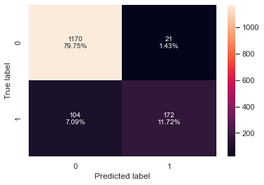

```python
#The confusion matrix for the model on the test set
confusion_matrix_sklearn(bagging, X_test, y_test)
```

#### Observations

True Positive: The model predicted customer will buy a travel package, and customer bought a travel package. This is 11.72% for the bagging classifier ensemble model. False Positive: The model predicted that customer will buy a travel package, and customer did not buy a travel package. This is where predicted = 1, but observed = 0. This is 1.43% above on the test set. We want to reduce the false positives, so the bagging classifier has less false positives than the decision tree. True Negative: The model predicted that the customer will not buy a package, and the customer did not buy a travel package. This is where predicted = 0, and observed = 0. This is 79.75%. False Negative: The model predicted that the customer will not buy a package, and the customer bought a package. This is where predicted = 0, observed = 1. This is 7.09% in the above test set performance.

```python
#Training performance evaluation
bagging_model_train_perf = model_performance_classification_sklearn(
    bagging, X_train, y_train
)
print("Training performance \n", bagging_model_train_perf)
```

```
Training performance
    Accuracy    Recall  Precision        F1
0  0.993861  0.968944     0.9984  0.983452
```

#### Observations

The 98.34 for F1 and 96.8% recall are for training set.

```python
# Evaluation of the model on the testing set
bagging_model_test_perf = model_performance_classification_sklearn(
    bagging, X_test, y_test
)
print("Testing performance \n", bagging_model_test_perf)
```

```
Testing performance
    Accuracy    Recall  Precision        F1
0  0.914792  0.623188   0.891192  0.733475
```

#### Bagging classifier with weighted decision tree

```python
bagging_wt = BaggingClassifier(
    base_estimator=DecisionTreeClassifier(
        criterion="gini", class_weight={0: 0.19, 1: 0.81}, random_state=1
    ),
    random_state=1,
)
bagging_wt.fit(X_train, y_train)
```

```
BaggingClassifier(base_estimator=DecisionTreeClassifier(class_weight={0: 0.19,
                                                                      1: 0.81},
                                                        random_state=1),
                  random_state=1)
```

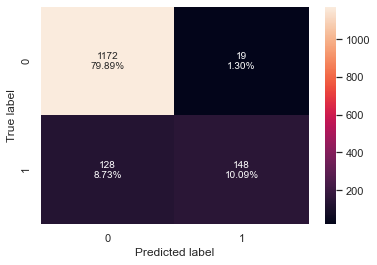

```python
confusion_matrix_sklearn(bagging_wt, X_test, y_test)
```

#### Observations

True Positive: The model predicted customer will buy a travel package, and customer bought a travel package. This is 10.09% for the bagging classifier with a weighted decision tree model. False Positive: The model predicted that customer will buy a travel package, and customer did not buy a travel package. This is where predicted = 1, but observed = 0. This is 1.3% above on the test set. We want to reduce the false positives, so the bagging classifier has less false positives than the decision tree. True Negative: The model predicted that the customer will not buy a package, and the customer did not buy a travel package. This is where predicted = 0, and observed = 0. This is 79.89%. False Negative: The model predicted that the customer will not buy a package, and the customer bought a package. This is where predicted = 0, observed = 1. This is 8.73% in the above test set performance.

```python
# performance on training set for bagging classifier with weighted decision tree
bagging_wt_model_train_perf = model_performance_classification_sklearn(
    bagging_wt, X_train, y_train
)
print("Training performance \n", bagging_wt_model_train_perf)
```

```
Training performance
    Accuracy    Recall  Precision        F1
0  0.992692  0.964286    0.99679  0.980268
```

#### Observations

This is training set performance: approximately 98% F1, and a recall of 96% and precision of 99%.

```python
# Evaluation of bagging classifier with weighted decision tree
bagging_wt_model_test_perf = model_performance_classification_sklearn(
    bagging_wt, X_test, y_test
)
print("Testing performance \n", bagging_wt_model_test_perf)
```

```
Testing performance
    Accuracy    Recall  Precision        F1
0  0.899796  0.536232   0.886228  0.668172
```

#### Observations

The recall for the testing set is 53.6%, and precision is 88.6% and F1 is 66.8%. There is still a large difference between how the model performs for the training set and the testing set. This indicates that the model is still overfitting.

### Random Forest Model

```python
rf = RandomForestClassifier(random_state=1)
rf.fit(X_train, y_train)
```

```
RandomForestClassifier(random_state=1)
```

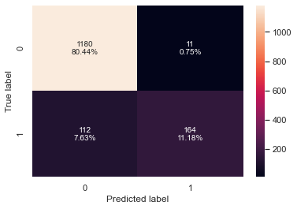

```python
# Confusion matrix for the testing set
confusion_matrix_sklearn(rf, X_test, y_test)
```

#### Observations

True Positive: The model predicted customer will buy a travel package, and customer bought a travel package. This is 11.18% for the random forest model. False Positive: The model predicted that customer will buy a travel package, and customer did not buy a travel package. This is where predicted = 1, but observed = 0. This is 0.75% above on the test set. We want to reduce the false positives, so the random forest model has less false positives than the decision tree and bagging models. True Negative: The model predicted that the customer will not buy a package, and the customer did not buy a travel package. This is where predicted = 0, and observed = 0. This is 80.44%. False Negative: The model predicted that the customer will not buy a package, and the customer bought a package. This is where predicted = 0, observed = 1. This is 7.63% in the above test set performance.

```python
#Training set performance evaluation
rf_model_train_perf = model_performance_classification_sklearn(rf, X_train, y_train)
print("Training performance \n", rf_model_train_perf)
```

```
Training performance
    Accuracy  Recall  Precision   F1
0       1.0     1.0        1.0  1.0
```

#### Observations

The model performed with 100% for all metrics for random forest.

```python
# Evaluation on testing set
rf_model_test_perf = model_performance_classification_sklearn(rf, X_test, y_test)
print("Testing performance \n", rf_model_test_perf)
```

```
Testing performance
    Accuracy    Recall  Precision        F1
0  0.916155  0.594203   0.937143  0.727273
```

### Random forest with class weights

```python
rf_wt = RandomForestClassifier(class_weight={0: 0.19, 1: 0.81}, random_state=1)
rf_wt.fit(X_train, y_train)
```

```
RandomForestClassifier(class_weight={0: 0.19, 1: 0.81}, random_state=1)
```

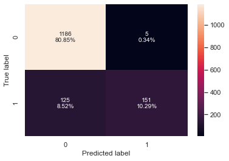

```python
#Confusion matrix for test set
confusion_matrix_sklearn(rf_wt, X_test, y_test)
```

#### Observations

True Positive: The model predicted customer will buy a travel package, and customer bought a travel package. This is 10.29% for the random forest with weights model. False Positive: The model predicted that customer will buy a travel package, and customer did not buy a travel package. This is where predicted = 1, but observed = 0. This is 0.34% above on the test set. We want to reduce the false positives, so the random forest model has less false positives than the decision tree and bagging models. True Negative: The model predicted that the customer will not buy a package, and the customer did not buy a travel package. This is where predicted = 0, and observed = 0. This is 80.85%. False Negative: The model predicted that the customer will not buy a package, and the customer bought a package. This is where predicted = 0, observed = 1. This is 8.52% in the above test set performance.

```python
# Training performance
rf_wt_model_train_perf = model_performance_classification_sklearn(
    rf_wt, X_train, y_train
)
print("Training performance \n", rf_wt_model_train_perf)
```

```
Training performance
    Accuracy  Recall  Precision   F1
0       1.0     1.0        1.0  1.0
```

#### Observations

The metrics for random forest with class weights is 100% on a training set.

```python
# Testing performance
rf_wt_model_test_perf = model_performance_classification_sklearn(rf_wt, X_test, y_test)
print("Testing performance \n", rf_wt_model_test_perf)
```

```
Testing performance
    Accuracy    Recall  Precision        F1
0  0.911384  0.547101   0.967949  0.699074
```

### Improving the above 3 models: hypertuning decision tree, bagging, random forest

#### Hypertuning decision tree

```python
from sklearn.metrics import (
    f1_score,
    accuracy_score,
    recall_score,
    precision_score,
    confusion_matrix,
    plot_confusion_matrix,
    make_scorer,
    roc_auc_score,
    precision_recall_curve,
    roc_curve,
)

from sklearn import metrics
```

```python
# Choose the type of classifier.
dtree_estimator = DecisionTreeClassifier(
    class_weight={0: 0.19, 1: 0.81}, random_state=1
)

# Grid of parameters to choose from
parameters = {
    "max_depth": np.arange(2, 30),
    "min_samples_leaf": [1, 2, 5, 7, 10],
    "max_leaf_nodes": [2, 3, 5, 10, 15],
    "min_impurity_decrease": [0.0001, 0.001, 0.01, 0.1],
}

# Type of scoring used to compare parameter combinations
scorer = metrics.make_scorer(metrics.recall_score)

# Run the grid search
grid_obj = GridSearchCV(dtree_estimator, parameters, scoring=scorer)
grid_obj = grid_obj.fit(X_train, y_train)

# Set the clf to the best combination of parameters
dtree_estimator = grid_obj.best_estimator_

# Fit the best algorithm to the data.
dtree_estimator.fit(X_train, y_train)
```

```
DecisionTreeClassifier(class_weight={0: 0.19, 1: 0.81}, max_depth=6,
                       max_leaf_nodes=15, min_impurity_decrease=0.0001,
                       random_state=1)
```

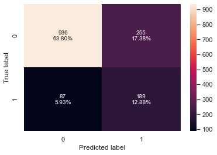

```python
#confusion matrix for the testing set
confusion_matrix_sklearn(dtree_estimator, X_test, y_test)
```

#### Observations

True Positive: The model predicted customer will buy a travel package, and customer bought a travel package. This is 12.88% for the hypertuned decision tree model. False Positive: The model predicted that customer will buy a travel package, and customer did not buy a travel package. This is where predicted = 1, but observed = 0. This is 17.38% above on the test set. We want to reduce the false positives, so the random forest model has less false positives than the decision tree and bagging models. True Negative: The model predicted that the customer will not buy a package, and the customer did not buy a travel package. This is where predicted = 0, and observed = 0. This is 63.8%. False Negative: The model predicted that the customer will not buy a package, and the customer bought a package. This is where predicted = 0, observed = 1. This is 5.93% in the above test set performance.

```python
#training performance for decision tree with hypertuning
dtree_estimator_model_train_perf = model_performance_classification_sklearn(
    dtree_estimator, X_train, y_train
)
print("Training performance \n", dtree_estimator_model_train_perf)
```

```
Training performance
    Accuracy    Recall  Precision        F1
0  0.754458  0.690994   0.409761  0.514451
```

#### Observations

```python
#testing performance for decision tree with hypertuning
dtree_estimator_model_test_perf = model_performance_classification_sklearn(
    dtree_estimator, X_test, y_test
)
print("Testing performance \n", dtree_estimator_model_test_perf)
```

```
Testing performance
    Accuracy    Recall  Precision     F1
0  0.766871  0.684783   0.425676  0.525
```

#### Observations

On the testing set, the hypertuned decision tree has a similar performance for recall (68.4%). However, the precision is 42% approximately and the F1...while it is close to training set, is quite low at 52.5%. This indicates that the decision tree is not overfitting, but it is also not performing adequately on either the training set or testing set.

#### Hypertuning bagging classifier

```python
# grid search for bagging classifier
cl1 = DecisionTreeClassifier(class_weight={0: 0.19, 1: 0.81}, random_state=1)
param_grid = {
    "base_estimator": [cl1],
    "n_estimators": [5, 7, 15, 51, 101],
    "max_features": [0.7, 0.8, 0.9, 1],
}

grid = GridSearchCV(
    BaggingClassifier(random_state=1, bootstrap=True),
    param_grid=param_grid,
    scoring="recall",
    cv=5,
)
grid.fit(X_train, y_train)
```

```
GridSearchCV(cv=5, estimator=BaggingClassifier(random_state=1),
             param_grid={'base_estimator': [DecisionTreeClassifier(class_weight={0: 0.19,
                                                                                 1: 0.81},
                                                                   random_state=1)],
                         'max_features': [0.7, 0.8, 0.9, 1],
                         'n_estimators': [5, 7, 15, 51, 101]},
             scoring='recall')
```

```python
## getting the best estimator
bagging_estimator = grid.best_estimator_
bagging_estimator.fit(X_train, y_train)
```

```
BaggingClassifier(base_estimator=DecisionTreeClassifier(class_weight={0: 0.19,
                                                                      1: 0.81},
                                                        random_state=1),
                  max_features=1, n_estimators=51, random_state=1)
```

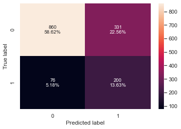

```python
#confusion matrix for testing set
confusion_matrix_sklearn(bagging_estimator, X_test, y_test)
```

#### Observations

True Positive: The model predicted customer will buy a travel package, and customer bought a travel package. This is 13.63% for the hypertuned bagging model. False Positive: The model predicted that customer will buy a travel package, and customer did not buy a travel package. This is where predicted = 1, but observed = 0. This is 22.56% above on the test set. True Negative: The model predicted that the customer will not buy a package, and the customer did not buy a travel package. This is where predicted = 0, and observed = 0. This is 58.62%. False Negative: The model predicted that the customer will not buy a package, and the customer bought a package. This is where predicted = 0, observed = 1. This is 5.18% in the above test set performance.

```python
#training performance for hypertuned bagging classifier
bagging_estimator_model_train_perf = model_performance_classification_sklearn(
    bagging_estimator, X_train, y_train
)
print("Training performance \n", bagging_estimator_model_train_perf)
```

```
Training performance
    Accuracy    Recall  Precision        F1
0  0.731073  0.703416   0.383249  0.496166
```

#### Observations

The recall on the training set is 70.3% and the precision is very low at 38.3%. The F1 is 49%.

```python
#testing set performance for hypertuned bagging classifier
bagging_estimator_model_test_perf = model_performance_classification_sklearn(
    bagging_estimator, X_test, y_test
)
print("Testing performance \n", bagging_estimator_model_test_perf)
```

```
Testing performance
    Accuracy    Recall  Precision        F1
0  0.722563  0.724638   0.376648  0.495663
```

#### Observations

The recall at the testing set is much better for the hypertuned bagging classifier model. The precision is low, at 37.6% and the F1 is 49.56%. While these numbers are close to the training set, it also means that the model has a large number of false positives and false negatives.

#### Hypertuning random forest

```python
# Choose the type of classifier.
rf_estimator = RandomForestClassifier(random_state=1)

# Grid of parameters to choose from
parameters = {
    "n_estimators": [110, 251, 501],
    "min_samples_leaf": np.arange(1, 6, 1),
    "max_features": [0.7, 0.9, "log2", "auto"],
    "max_samples": [0.7, 0.9, None],
}

# Run the grid search
grid_obj = GridSearchCV(rf_estimator, parameters, scoring="recall", cv=5)
grid_obj = grid_obj.fit(X_train, y_train)

# Set the clf to the best combination of parameters
rf_estimator = grid_obj.best_estimator_

# Fit the best algorithm to the data.
rf_estimator.fit(X_train, y_train)
```

```
RandomForestClassifier(max_features=0.9, n_estimators=251, random_state=1)
```

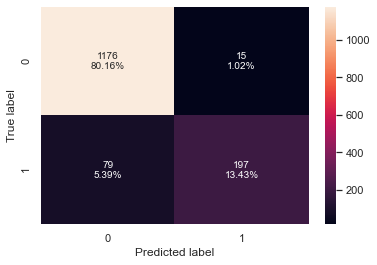

```python
# confusion matrix for testing set
confusion_matrix_sklearn(rf_estimator, X_test, y_test)
```

#### Observations

True Positive: The model predicted customer will buy a travel package, and customer bought a travel package. This is 13.43% for the hypertuned random forest model. False Positive: The model predicted that customer will buy a travel package, and customer did not buy a travel package. This is where predicted = 1, but observed = 0. This is 1.02% above on the test set. True Negative: The model predicted that the customer will not buy a package, and the customer did not buy a travel package. This is where predicted = 0, and observed = 0. This is 80.16%. False Negative: The model predicted that the customer will not buy a package, and the customer bought a package. This is where predicted = 0, observed = 1. This is 5.39% in the above test set performance.

```python
# training set performance for hypertuned random forest
rf_estimator_model_train_perf = model_performance_classification_sklearn(
    rf_estimator, X_train, y_train
)
print("Training performance \n", rf_estimator_model_train_perf)
```

```
Training performance
    Accuracy  Recall  Precision   F1
0       1.0     1.0        1.0  1.0
```

#### Observations

The hypertuned random forest model has 100% on training set.

```python
#testing set performance for hypertuned random forest
rf_estimator_model_test_perf = model_performance_classification_sklearn(
    rf_estimator, X_test, y_test
)
print("Testing performance \n", rf_estimator_model_test_perf)
```

```
Testing performance
    Accuracy    Recall  Precision        F1
0  0.935924  0.713768   0.929245  0.807377
```

#### Training performance comparision for above models

#### Observations

```python
# training performance comparison

models_train_comp_df = pd.concat(
    [
        dtree_model_train_perf.T,
        bagging_model_train_perf.T,
        bagging_wt_model_train_perf.T,
        rf_model_train_perf.T,
        rf_wt_model_train_perf.T,
        dtree_estimator_model_train_perf.T,
        bagging_estimator_model_train_perf.T,
        rf_estimator_model_train_perf.T,
    ],
    axis=1,
)
models_train_comp_df.columns = [
    "Decision Tree",
    "Bagging Classifier",
    "Weighted Bagging Classifier",
    "Random Forest Classifier",
    "Weighted Random Forest Classifier",
    "Decision Tree Estimator",
    "Bagging Estimator",
    "Random Forest Estimator",
]
print("Training performance comparison:")
models_train_comp_df
```

```
Training performance comparison:
```

|  | Decision Tree | Bagging Classifier | Weighted Bagging Classifier | Random Forest Classifier | Weighted Random Forest Classifier | Decision Tree Estimator | Bagging Estimator | Random Forest Estimator |
| --- | --- | --- | --- | --- | --- | --- | --- | --- |
| Accuracy | 1.0 | 0.993861 | 0.992692 | 1.0 | 1.0 | 0.754458 | 0.731073 | 1.0 |
| Recall | 1.0 | 0.968944 | 0.964286 | 1.0 | 1.0 | 0.690994 | 0.703416 | 1.0 |
| Precision | 1.0 | 0.998400 | 0.996790 | 1.0 | 1.0 | 0.409761 | 0.383249 | 1.0 |
| F1 | 1.0 | 0.983452 | 0.980268 | 1.0 | 1.0 | 0.514451 | 0.496166 | 1.0 |

#### Observations

Several models had close to 100% or 100% on their training sets. Unfortunately, this indicates that the model was likely overfitting.

```python
# testing performance comparison

models_test_comp_df = pd.concat(
    [
        dtree_model_test_perf.T,
        bagging_model_test_perf.T,
        bagging_wt_model_test_perf.T,
        rf_model_test_perf.T,
        rf_wt_model_test_perf.T,
        dtree_estimator_model_test_perf.T,
        bagging_estimator_model_test_perf.T,
        rf_estimator_model_test_perf.T,
    ],
    axis=1,
)
models_test_comp_df.columns = [
    "Decision Tree",
    "Bagging Classifier",
    "Weighted Bagging Classifier",
    "Random Forest Classifier",
    "Weighted Random Forest Classifier",
    "Decision Tree Estimator",
    "Bagging Estimator",
    "Random Forest Estimator",
]
print("Testing performance comparison:")
models_test_comp_df
```

```
Testing performance comparison:
```

|  | Decision Tree | Bagging Classifier | Weighted Bagging Classifier | Random Forest Classifier | Weighted Random Forest Classifier | Decision Tree Estimator | Bagging Estimator | Random Forest Estimator |
| --- | --- | --- | --- | --- | --- | --- | --- | --- |
| Accuracy | 0.882072 | 0.914792 | 0.899796 | 0.916155 | 0.911384 | 0.766871 | 0.722563 | 0.935924 |
| Recall | 0.648551 | 0.623188 | 0.536232 | 0.594203 | 0.547101 | 0.684783 | 0.724638 | 0.713768 |
| Precision | 0.701961 | 0.891192 | 0.886228 | 0.937143 | 0.967949 | 0.425676 | 0.376648 | 0.929245 |
| F1 | 0.674200 | 0.733475 | 0.668172 | 0.727273 | 0.699074 | 0.525000 | 0.495663 | 0.807377 |

#### Observations

On the testing set, for accuracy - the model that gave the best accuracy was random forest estimator. However, accuracy is not the most important measure of performance as explained in the beginning of the model building section. For recall, the best model was bagging estimator, and the next best was random forest estimator. For precision, the weighted random forest classifier was the best performing model. For F1, the random forest estimator (the hypertuned) gave the best F1 score.  
However, for the current problem of predicting which customer will buy a travel package, the recall and F1 are more important scores as compared to precision and accuracy. This is because we want to reduce the false positivies as much as possible. Thus, analyzing the above table - we can say that the random forest estimator (the hypertuned model) peformed best for the above testing set (80.7% F1, 71% recall).

```python
# importance of features in the tree building ( The importance of a feature is computed as the
# (normalized) total reduction of the criterion brought by that feature. It is also known as the Gini importance )

print(
    pd.DataFrame(
        rf.feature_importances_, columns=["Imp"], index=X_train.columns
    ).sort_values(by="Imp", ascending=False)
)
```

```
                                  Imp
Age                          0.125429
MonthlyIncome_z_std          0.124869
DurationOfPitch              0.101200
Passport_1                   0.069543
NumberOfTrips                0.065081
PitchSatisfactionScore       0.056396
NumberOfFollowups            0.056145
PreferredPropertyStar        0.042130
CityTier                     0.037945
NumberOfChildrenVisiting     0.033541
Designation_Executive        0.028867
NumberOfPersonVisiting       0.027602
MaritalStatus_Single         0.027475
Gender_Male                  0.026532
TypeofContact_Self Enquiry   0.024505
OwnCar_1                     0.021798
Occupation_Small Business    0.020051
Occupation_Salaried          0.018695
MaritalStatus_Married        0.016563
MaritalStatus_Unmarried      0.015665
Occupation_Large Business    0.015585
Designation_Manager          0.011445
ProductPitched_Deluxe        0.008977
Designation_Senior Manager   0.007004
ProductPitched_Standard      0.006420
ProductPitched_Super Deluxe  0.005668
Designation_VP               0.002568
ProductPitched_King          0.002300
```

```python
feature_names = X_train.columns
```

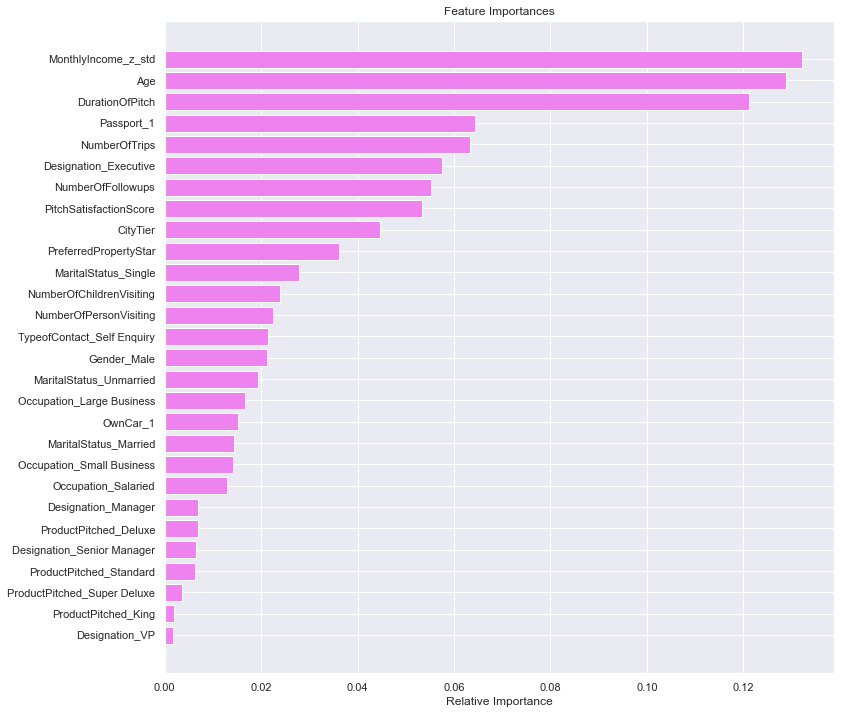

```python
importances = rf_estimator.feature_importances_
indices = np.argsort(importances)

plt.figure(figsize=(12, 12))
plt.title("Feature Importances")
plt.barh(range(len(indices)), importances[indices], color="violet", align="center")
plt.yticks(range(len(indices)), [feature_names[i] for i in indices])
plt.xlabel("Relative Importance")
plt.show()
```

#### Observations

The most important features that influenced the model was the monthly income, age and duration of pitch.

### 9. Boosting models - Adaboost, gradient descent, XGBoost. The Adaboost and gradient descent models will be hypertuned.

#### Adaboost

```python
from sklearn.ensemble import AdaBoostClassifier, GradientBoostingClassifier
```

```python
## Function to create confusion matrix
def make_confusion_matrix(model, y_actual, labels=[1, 0]):
    """
    model : classifier to predict values of X
    y_actual : ground truth

    """
    y_predict = model.predict(X_test)
    cm = metrics.confusion_matrix(y_actual, y_predict, labels=[0, 1])
    df_cm = pd.DataFrame(
        cm,
        index=[i for i in ["Actual - No", "Actual - Yes"]],
        columns=[i for i in ["Predicted - No", "Predicted - Yes"]],
    )
    group_counts = ["{0:0.0f}".format(value) for value in cm.flatten()]
    group_percentages = ["{0:.2%}".format(value) for value in cm.flatten() / np.sum(cm)]
    labels = [f"{v1}\n{v2}" for v1, v2 in zip(group_counts, group_percentages)]
    labels = np.asarray(labels).reshape(2, 2)
    plt.figure(figsize=(10, 7))
    sns.heatmap(df_cm, annot=labels, fmt="")
    plt.ylabel("True label")
    plt.xlabel("Predicted label")
```

```python
##  Function to calculate different metric scores of the model - Accuracy, Recall and Precision
def get_metrics_score(model, flag=True):
    """
    model : classifier to predict values of X

    """
    # defining an empty list to store train and test results
    score_list = []

    pred_train = model.predict(X_train)
    pred_test = model.predict(X_test)

    train_acc = model.score(X_train, y_train)
    test_acc = model.score(X_test, y_test)

    train_recall = metrics.recall_score(y_train, pred_train)
    test_recall = metrics.recall_score(y_test, pred_test)

    train_precision = metrics.precision_score(y_train, pred_train)
    test_precision = metrics.precision_score(y_test, pred_test)

    train_F1 = metrics.f1_score(y_train, pred_train)
    test_F1 = metrics.f1_score(y_test, pred_test)

    score_list.extend(
        (
            train_acc,
            test_acc,
            train_recall,
            test_recall,
            train_precision,
            test_precision,
            train_F1,
            test_F1
        )
    )

    # If the flag is set to True then only the following print statements will be dispayed. The default value is set to True.
    if flag == True:
        print("Accuracy on training set : ", model.score(X_train, y_train))
        print("Accuracy on test set : ", model.score(X_test, y_test))
        print("Recall on training set : ", metrics.recall_score(y_train, pred_train))
        print("Recall on test set : ", metrics.recall_score(y_test, pred_test))
        print(
            "Precision on training set : ", metrics.precision_score(y_train, pred_train)
        )
        print("Precision on test set : ", metrics.precision_score(y_test, pred_test))
        print(
            "F1 on training set : ", metrics.f1_score(y_train, pred_train)
        )
        print("F1 on test set : ", metrics.f1_score(y_test, pred_test))

    return score_list  # returning the list with train and test scores
```

```python
abc = AdaBoostClassifier(random_state=1)
abc.fit(X_train, y_train)
```

```
AdaBoostClassifier(random_state=1)
```

```python
# Getting the performance measures for both training and testing set for Adaboost
abc_score = get_metrics_score(abc)
```

```
Accuracy on training set :  0.8488745980707395
Accuracy on test set :  0.8445807770961146
Recall on training set :  0.32298136645962733
Recall on test set :  0.3079710144927536
Precision on training set :  0.7197231833910035
Precision on test set :  0.6967213114754098
F1 on training set :  0.4458735262593783
F1 on test set :  0.42713567839195976
```

#### Observations

1. The accuracy metrics on both training set and testing set are close. As are the recall, precision and F1 scores.
2. The recall scores on both training and testing set are approximately 30% while precision is almost 70%. This results in low F1 scores, that are below 50%.

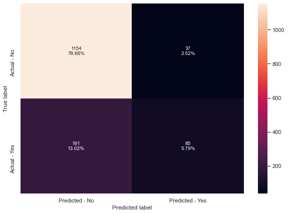

```python
#Confusion matrix on the testing set for Adaboost
make_confusion_matrix(abc, y_test)
```

#### Observations

True Positive: The model predicted customer will buy a travel package, and customer bought a travel package. This is 5.79% for the adaboost model which is very low. False Positive: The model predicted that customer will buy a travel package, and customer did not buy a travel package. This is where predicted = 1, but observed = 0. This is 2.52% above on the test set. True Negative: The model predicted that the customer will not buy a package, and the customer did not buy a travel package. This is where predicted = 0, and observed = 0. This is 78.66%. False Negative: The model predicted that the customer will not buy a package, and the customer bought a package. This is where predicted = 0, observed = 1. This is 13.02% in the above test set performance.

#### Gradient boost Models

```python
gbc = GradientBoostingClassifier(random_state=1)
gbc.fit(X_train, y_train)
```

```
GradientBoostingClassifier(random_state=1)
```

```python
# Performance measures on the testing set for gradient descent models
gbc_score = get_metrics_score(gbc)
```

```
Accuracy on training set :  0.887459807073955
Accuracy on test set :  0.8657123381049762
Recall on training set :  0.453416149068323
Recall on test set :  0.38768115942028986
Precision on training set :  0.8984615384615384
Precision on test set :  0.7925925925925926
F1 on training set :  0.6026831785345717
F1 on test set :  0.5206812652068126
```

#### Observations

The performance measures are close between the training and testing set. However, the recall is 38% on the testing set, and while precision is 79% on the testing set, the F1 scores become low at 52%.

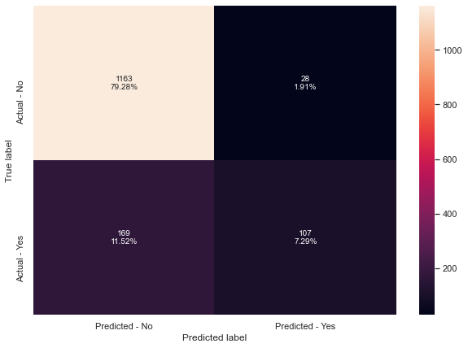

```python
# Confusion matrix for gradient descent model on testing set
make_confusion_matrix(gbc, y_test)
```

#### Observations

```python
# Hypertuning the adaboost model
abc_tuned = AdaBoostClassifier(random_state=1)

# Grid of parameters to choose from
## add from article
parameters = {
    # Let's try different max_depth for base_estimator
    "base_estimator": [
        DecisionTreeClassifier(max_depth=1, random_state=1),
        DecisionTreeClassifier(max_depth=2, random_state=1),
        DecisionTreeClassifier(max_depth=3, random_state=1),
    ],
    "n_estimators": np.arange(10, 110, 10),
    "learning_rate": np.arange(0.1, 2, 0.1),
}

# Type of scoring used to compare parameter combinations
acc_scorer = metrics.make_scorer(metrics.recall_score)

# Run the grid search
grid_obj = GridSearchCV(abc_tuned, parameters, scoring=acc_scorer, cv=5)
grid_obj = grid_obj.fit(X_train, y_train)

# Set the clf to the best combination of parameters
abc_tuned = grid_obj.best_estimator_

# Fit the best algorithm to the data.
abc_tuned.fit(X_train, y_train)
```

```
AdaBoostClassifier(base_estimator=DecisionTreeClassifier(max_depth=3,
                                                         random_state=1),
                   learning_rate=1.7000000000000002, n_estimators=100,
                   random_state=1)
```

```python
#Performance measures for hypertuned adaboost model on the training and testing sets
abc_tuned_score = get_metrics_score(abc_tuned)
```

```
Accuracy on training set :  0.9818766442560655
Accuracy on test set :  0.8732106339468303
Recall on training set :  0.9316770186335404
Recall on test set :  0.6123188405797102
Precision on training set :  0.970873786407767
Precision on test set :  0.6814516129032258
F1 on training set :  0.9508716323296356
F1 on test set :  0.6450381679389313
```

#### Observations

There are large differences between the model performance on the training set versus the testing set. For example, recall on training set is 93%, while on testing set is 61%. The differences are similar for precision and F1 between training and testing sets.

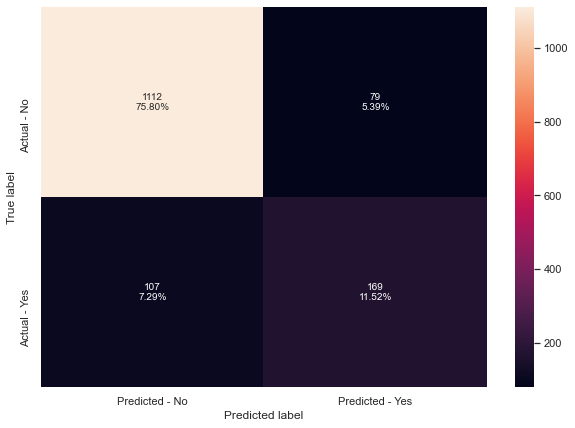

```python
#Confusion matrix for tuned adaboost model on testing set
make_confusion_matrix(abc_tuned, y_test)
```

#### Observations

True Positive: The model predicted customer will buy a travel package, and customer bought a travel package. This is 11.52% for the tuned adaboost model which is very low. False Positive: The model predicted that customer will buy a travel package, and customer did not buy a travel package. This is where predicted = 1, but observed = 0. This is 5.39% above on the test set. True Negative: The model predicted that the customer will not buy a package, and the customer did not buy a travel package. This is where predicted = 0, and observed = 0. This is 75.8%. False Negative: The model predicted that the customer will not buy a package, and the customer bought a package. This is where predicted = 0, observed = 1. This is 7.29% in the above test set performance.

```python
gbc_init = GradientBoostingClassifier(
    init=AdaBoostClassifier(random_state=1), random_state=1
)
gbc_init.fit(X_train, y_train)
```

```
GradientBoostingClassifier(init=AdaBoostClassifier(random_state=1),
                           random_state=1)
```

```python
# performance measures on training and testing set for gradient boost model
gbc_init_score = get_metrics_score(gbc_init)
```

```
Accuracy on training set :  0.8918444899152295
Accuracy on test set :  0.8738922972051807
Recall on training set :  0.4751552795031056
Recall on test set :  0.42391304347826086
Precision on training set :  0.9053254437869822
Precision on test set :  0.8181818181818182
F1 on training set :  0.6232179226069247
F1 on test set :  0.558472553699284
```

#### Observations

The model has similar scores between training and testing sets. The model has precision of 81.8% on testing set, however the recall is 42.3%.

```python
# hypertuning the gradient boost model
gbc_tuned = GradientBoostingClassifier(
    init=AdaBoostClassifier(random_state=1), random_state=1
)

# Grid of parameters to choose from
## add from article
parameters = {
    "n_estimators": [100, 150, 200, 250],
    "subsample": [0.8, 0.9, 1],
    "max_features": [0.7, 0.8, 0.9, 1],
}

# Type of scoring used to compare parameter combinations
acc_scorer = metrics.make_scorer(metrics.recall_score)

# Run the grid search
grid_obj = GridSearchCV(gbc_tuned, parameters, scoring=acc_scorer, cv=5)
grid_obj = grid_obj.fit(X_train, y_train)

# Set the clf to the best combination of parameters
gbc_tuned = grid_obj.best_estimator_

# Fit the best algorithm to the data.
gbc_tuned.fit(X_train, y_train)
```

```
GradientBoostingClassifier(init=AdaBoostClassifier(random_state=1),
                           max_features=0.9, n_estimators=250, random_state=1,
                           subsample=0.8)
```

```python
# Performance measures for the tuned gradient boost model
gbc_tuned_score = get_metrics_score(gbc_tuned)
```

```
Accuracy on training set :  0.9245834551300789
Accuracy on test set :  0.8847989093387867
Recall on training set :  0.6335403726708074
Recall on test set :  0.4855072463768116
Precision on training set :  0.9488372093023256
Precision on test set :  0.8322981366459627
F1 on training set :  0.7597765363128491
F1 on test set :  0.6132723112128147
```

#### Observations

The recall scores on training 63.3% versus the recall scores on testing set 48.5% is quite large. The differences are smaller for precision and F1.

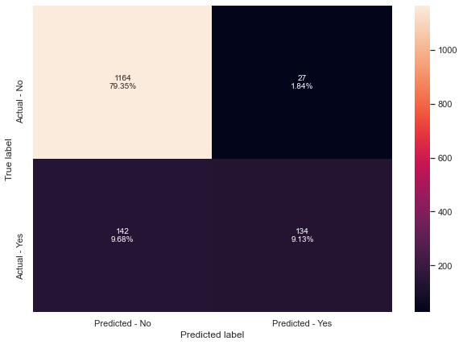

```python
#confusion matrix for tuned gradient boost models
make_confusion_matrix(gbc_tuned, y_test)
```

#### Observations

True Positive: The model predicted customer will buy a travel package, and customer bought a travel package. This is 9.13% for the tuned gradient boost model which is very low. False Positive: The model predicted that customer will buy a travel package, and customer did not buy a travel package. This is where predicted = 1, but observed = 0. This is 1.84% above on the test set. True Negative: The model predicted that the customer will not buy a package, and the customer did not buy a travel package. This is where predicted = 0, and observed = 0. This is 79.35%. False Negative: The model predicted that the customer will not buy a package, and the customer bought a package. This is where predicted = 0, observed = 1. This is 9.68% in the above test set performance.

```python
# importance of features in the tree building ( The importance of a feature is computed as the
#(normalized) total reduction of the criterion brought by that feature. It is also known as the Gini importance )

print(pd.DataFrame(gbc_tuned.feature_importances_, columns = ["Imp"], index = X_train.columns).sort_values(by = 'Imp', ascending = False))
```

```
                                  Imp
MonthlyIncome_z_std          0.197614
Age                          0.136791
Passport_1                   0.125951
DurationOfPitch              0.085251
Designation_Executive        0.076332
NumberOfFollowups            0.056684
CityTier                     0.051100
NumberOfTrips                0.041518
MaritalStatus_Single         0.040783
PitchSatisfactionScore       0.032409
PreferredPropertyStar        0.032243
MaritalStatus_Unmarried      0.022737
Occupation_Large Business    0.013142
TypeofContact_Self Enquiry   0.012435
Gender_Male                  0.009910
ProductPitched_Standard      0.009555
Designation_Manager          0.007853
NumberOfChildrenVisiting     0.007722
Designation_Senior Manager   0.007604
MaritalStatus_Married        0.006165
ProductPitched_Super Deluxe  0.005739
OwnCar_1                     0.003841
NumberOfPersonVisiting       0.003645
Occupation_Small Business    0.003521
ProductPitched_Deluxe        0.003016
Occupation_Salaried          0.002701
Designation_VP               0.002225
ProductPitched_King          0.001514
```

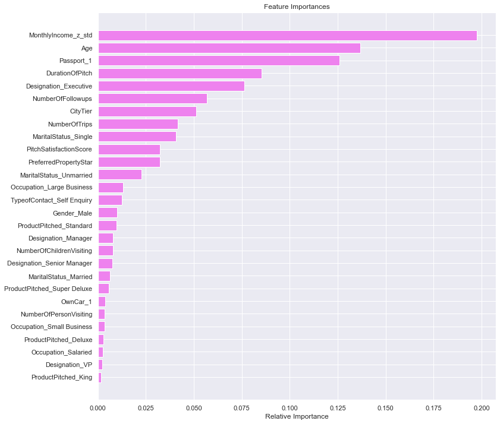

```python
feature_names = X_train.columns
importances = gbc_tuned.feature_importances_
indices = np.argsort(importances)

plt.figure(figsize=(12,12))
plt.title('Feature Importances')
plt.barh(range(len(indices)), importances[indices], color='violet', align='center')
plt.yticks(range(len(indices)), [feature_names[i] for i in indices])
plt.xlabel('Relative Importance')
plt.show()
```

#### Observation

Similar to the bagging models, the feature importance for boosting models is monthly income, followed by age and then passport.

### XGB Boost

```python
from xgboost import XGBClassifier
```

```
Training performance:
    Accuracy    Recall  Precision        F1
0  0.999708  0.998447        1.0  0.999223
Testing performance:
    Accuracy    Recall  Precision        F1
0  0.920927  0.673913   0.877358  0.762295
```

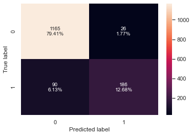

```python
#Fitting the model
xgb_classifier = XGBClassifier(random_state=1, eval_metric='logloss')
xgb_classifier.fit(X_train,y_train)

#Calculating different metrics
xgb_classifier_model_train_perf=model_performance_classification_sklearn(xgb_classifier,X_train,y_train)
print("Training performance:\n",xgb_classifier_model_train_perf)
xgb_classifier_model_test_perf=model_performance_classification_sklearn(xgb_classifier,X_test,y_test)
print("Testing performance:\n",xgb_classifier_model_test_perf)

#Creating confusion matrix
confusion_matrix_sklearn(xgb_classifier,X_test,y_test)
```

#### Observations

The XGBoost model performs very well on the training set, but has a recall of 67.3% for testing set. There are also large differences between the performance metrics for precision and F1. The confusion matrix shows that false positive rates were 1.77% which is low, however the true positive rate was 12.68%.

```python
# Choose the type of classifier.
xgb_tuned = XGBClassifier(random_state=1, eval_metric='logloss')

# Grid of parameters to choose from
parameters = {
    "n_estimators": [10,30,50],
    "scale_pos_weight":[1,2,5],
    "subsample":[0.7,0.9,1],
    "learning_rate":[0.05, 0.1,0.2],
    "colsample_bytree":[0.7,0.9,1],
    "colsample_bylevel":[0.5,0.7,1]
}

# Type of scoring used to compare parameter combinations
scorer = metrics.make_scorer(metrics.f1_score)

# Run the grid search
grid_obj = GridSearchCV(xgb_tuned, parameters,scoring=scorer,cv=5)
grid_obj = grid_obj.fit(X_train, y_train)

# Set the clf to the best combination of parameters
xgb_tuned = grid_obj.best_estimator_

# Fit the best algorithm to the data.
xgb_tuned.fit(X_train, y_train)
```

```
XGBClassifier(base_score=0.5, booster='gbtree', colsample_bylevel=1,
              colsample_bynode=1, colsample_bytree=1, eval_metric='logloss',
              gamma=0, gpu_id=-1, importance_type='gain',
              interaction_constraints='', learning_rate=0.2, max_delta_step=0,
              max_depth=6, min_child_weight=1, missing=nan,
              monotone_constraints='()', n_estimators=50, n_jobs=12,
              num_parallel_tree=1, random_state=1, reg_alpha=0, reg_lambda=1,
              scale_pos_weight=5, subsample=1, tree_method='exact',
              validate_parameters=1, verbosity=None)
```

```
Training performance:
    Accuracy    Recall  Precision        F1
0  0.977492  0.995342   0.896503  0.943341
Testing performance:
    Accuracy    Recall  Precision        F1
0  0.904567  0.807971   0.719355  0.761092
```

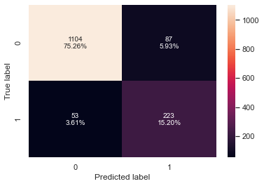

```python
#Calculating different metrics
xgb_tuned_model_train_perf=model_performance_classification_sklearn(xgb_tuned,X_train,y_train)
print("Training performance:\n",xgb_tuned_model_train_perf)
xgb_tuned_model_test_perf=model_performance_classification_sklearn(xgb_tuned,X_test,y_test)
print("Testing performance:\n",xgb_tuned_model_test_perf)

#Creating confusion matrix
confusion_matrix_sklearn(xgb_tuned,X_test,y_test)
```

#### Observations

For a tuned XGBoost model, the recall improved on the testing set to 80.7%, and the F1 score also increased to 76%. There are however still large differences between the training and testing metrics, indicating that further hypertuning may be needed.

```python
from sklearn.ensemble import StackingClassifier
```

```python
#stacking
estimators = [('Random Forest',rf_estimator), ('Gradient Boosting',gbc_tuned), ('Decision Tree',dtree_estimator)]

final_estimator = xgb_tuned

stacking_classifier= StackingClassifier(estimators=estimators,final_estimator=final_estimator)

stacking_classifier.fit(X_train,y_train)
```

```
StackingClassifier(estimators=[('Random Forest',
                                RandomForestClassifier(max_features=0.9,
                                                       n_estimators=251,
                                                       random_state=1)),
                               ('Gradient Boosting',
                                GradientBoostingClassifier(init=AdaBoostClassifier(random_state=1),
                                                           max_features=0.9,
                                                           n_estimators=250,
                                                           random_state=1,
                                                           subsample=0.8)),
                               ('Decision Tree',
                                DecisionTreeClassifier(class_weight={0: 0.19,
                                                                     1: 0.81},
                                                       max_depth...
                                                 eval_metric='logloss', gamma=0,
                                                 gpu_id=-1,
                                                 importance_type='gain',
                                                 interaction_constraints='',
                                                 learning_rate=0.2,
                                                 max_delta_step=0, max_depth=6,
                                                 min_child_weight=1,
                                                 missing=nan,
                                                 monotone_constraints='()',
                                                 n_estimators=50, n_jobs=12,
                                                 num_parallel_tree=1,
                                                 random_state=1, reg_alpha=0,
                                                 reg_lambda=1,
                                                 scale_pos_weight=5,
                                                 subsample=1,
                                                 tree_method='exact',
                                                 validate_parameters=1,
                                                 verbosity=None))
```

```
Training performance:
    Accuracy  Recall  Precision        F1
0  0.987138     1.0   0.936047  0.966967
Testing performance:
    Accuracy    Recall  Precision        F1
0  0.912747  0.844203   0.732704  0.784512
```

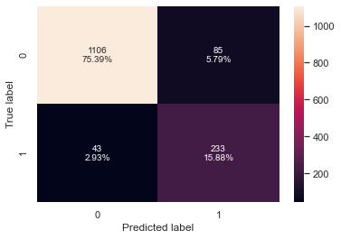

```python
#Calculating different metrics
stacking_classifier_model_train_perf=model_performance_classification_sklearn(stacking_classifier,X_train,y_train)
print("Training performance:\n",stacking_classifier_model_train_perf)
stacking_classifier_model_test_perf=model_performance_classification_sklearn(stacking_classifier,X_test,y_test)
print("Testing performance:\n",stacking_classifier_model_test_perf)

#Creating confusion matrix
confusion_matrix_sklearn(stacking_classifier,X_test,y_test)
```

#### Observations

The stacking model had a recall score of 84% approximately on the testing set, and a precision of 73% on the testing set, and an F1 score of 78% on the testing set. The FP was 5.79% and FN was 2.93%.

```python
# defining list of models
models = [abc, abc_tuned, gbc, gbc_init, gbc_tuned, xgb_classifier, xgb_tuned]

# defining empty lists to add train and test results
acc_train = []
acc_test = []
recall_train = []
recall_test = []
precision_train = []
precision_test = []
f1_train = []
f1_test = []

# looping through all the models to get the accuracy, precall and precision scores
for model in models:
    j = get_metrics_score(model,False)
    acc_train.append(np.round(j[0],2))
    acc_test.append(np.round(j[1],2))
    recall_train.append(np.round(j[2],2))
    recall_test.append(np.round(j[3],2))
    precision_train.append(np.round(j[4],2))
    precision_test.append(np.round(j[5],2))
    f1_train.append(np.round(j[4],2))
    f1_test.append(np.round(j[5],2))
```

```python
comparison_frame = pd.DataFrame({'Model':['AdaBoost with default paramters','AdaBoost Tuned',
                                          'Gradient Boosting with default parameters','Gradient Boosting with init=AdaBoost',
                                          'Gradient Boosting Tuned','XGBoost with default parameters','XGBoost Tuned'],
                                          'Train_Accuracy': acc_train,'Test_Accuracy': acc_test,
                                          'Train_Recall':recall_train,'Test_Recall':recall_test,
                                          'Train_Precision':precision_train,'Test_Precision':precision_test,
                                          'Train_F1':f1_train, 'Test_F1':f1_test})
comparison_frame
```

[output not shown]

#### 10. Insights and recommendations

1. Majority of the customer base is highly interested in tourism packages - given that 70.4% made a self enquiry about travel packages on their own. This indicates that if the right sort of travel package is offered to these customers, the likelihood that they will purchase a travel package is good.
2. 82% of the customers who did a self enquiry and 78% of the customers who were contacted by the company did not purchase a tourism package. This indicates that either the packages did not appeal to the customers or they could not afford the travel packages.
3. While Deluxe was the package that was pitched the most to customers, the Basic package was the one that was purchased most of the time. This indicates that there is a mismatch between what is being offered to the customer and what they actually want/or can afford.
4. The model predictions gave importance to monthly income and age and duration of pitch - hence, the marketing team can target customers based on their income (higher income bracket should be targeted more often) and age (younger customers for basic package). In addition, the duration of pitch can also influence whether the customer will ultimately buy the package or not, so the marketing department should strategize on how to engage the customer for an optimum duration while pitching the package product to them.
5. Overall, the potential to market a wellness tourism package is present - especially since the customer base is mostly manager designation or above (which involves long hours and stress, so a wellness package may seem attractive). However, since the customers prefer 3 star properties, and domestic locations, as well are in the younger age bracket - the wellness packages should incorporate these features into the product.